# Students’ Grades Prediction Data Exploration

The data used in this analysis is from https://www.kaggle.com/aljarah/xAPI-Edu-Data.

# Data Pre-Processing

```r
library(dplyr)
library(ggplot2)
library(gridExtra)
```

```r
grades <- read.csv("xAPI-Edu-Data.csv", stringsAsFactors = T)
grades$Class <- factor(grades$Class, levels = c("L", "M", "H"))
head(grades, 10)
```

|  | gender | NationalITy | PlaceofBirth | StageID | GradeID | SectionID | Topic | Semester | Relation | raisedhands | VisITedResources | AnnouncementsView | Discussion | ParentAnsweringSurvey | ParentschoolSatisfaction | StudentAbsenceDays | Class |
| --- | --- | --- | --- | --- | --- | --- | --- | --- | --- | --- | --- | --- | --- | --- | --- | --- | --- |
| 1 | M | KW | KuwaIT | lowerlevel | G-04 | A | IT | F | Father | 15 | 16 | 2 | 20 | Yes | Good | Under-7 | M |
| 2 | M | KW | KuwaIT | lowerlevel | G-04 | A | IT | F | Father | 20 | 20 | 3 | 25 | Yes | Good | Under-7 | M |
| 3 | M | KW | KuwaIT | lowerlevel | G-04 | A | IT | F | Father | 10 | 7 | 0 | 30 | No | Bad | Above-7 | L |
| 4 | M | KW | KuwaIT | lowerlevel | G-04 | A | IT | F | Father | 30 | 25 | 5 | 35 | No | Bad | Above-7 | L |
| 5 | M | KW | KuwaIT | lowerlevel | G-04 | A | IT | F | Father | 40 | 50 | 12 | 50 | No | Bad | Above-7 | M |
| 6 | F | KW | KuwaIT | lowerlevel | G-04 | A | IT | F | Father | 42 | 30 | 13 | 70 | Yes | Bad | Above-7 | M |
| 7 | M | KW | KuwaIT | MiddleSchool | G-07 | A | Math | F | Father | 35 | 12 | 0 | 17 | No | Bad | Above-7 | L |
| 8 | M | KW | KuwaIT | MiddleSchool | G-07 | A | Math | F | Father | 50 | 10 | 15 | 22 | Yes | Good | Under-7 | M |
| 9 | F | KW | KuwaIT | MiddleSchool | G-07 | A | Math | F | Father | 12 | 21 | 16 | 50 | Yes | Good | Under-7 | M |
| 10 | F | KW | KuwaIT | MiddleSchool | G-07 | B | IT | F | Father | 70 | 80 | 25 | 70 | Yes | Good | Under-7 | M |

```r
summary(grades)
```

```
 gender     NationalITy       PlaceofBirth         StageID       GradeID    SectionID     Topic
 F:175   KW       :179   KuwaIT     :180   HighSchool  : 33   G-02   :147   A:283     IT     : 95
 M:305   Jordan   :172   Jordan     :176   lowerlevel  :199   G-08   :116   B:167     French : 65
         Palestine: 28   Iraq       : 22   MiddleSchool:248   G-07   :101   C: 30     Arabic : 59
         Iraq     : 22   lebanon    : 19                      G-04   : 48             Science: 51
         lebanon  : 17   SaudiArabia: 16                      G-06   : 32             English: 45
         Tunis    : 12   USA        : 16                      G-11   : 13             Biology: 30
         (Other)  : 50   (Other)    : 51                      (Other): 23             (Other):135
 Semester   Relation    raisedhands     VisITedResources AnnouncementsView   Discussion
 F:245    Father:283   Min.   :  0.00   Min.   : 0.0     Min.   : 0.00     Min.   : 1.00
 S:235    Mum   :197   1st Qu.: 15.75   1st Qu.:20.0     1st Qu.:14.00     1st Qu.:20.00
                       Median : 50.00   Median :65.0     Median :33.00     Median :39.00
                       Mean   : 46.77   Mean   :54.8     Mean   :37.92     Mean   :43.28
                       3rd Qu.: 75.00   3rd Qu.:84.0     3rd Qu.:58.00     3rd Qu.:70.00
                       Max.   :100.00   Max.   :99.0     Max.   :98.00     Max.   :99.00

 ParentAnsweringSurvey ParentschoolSatisfaction StudentAbsenceDays Class
 No :210               Bad :188                 Above-7:191        L:127
 Yes:270               Good:292                 Under-7:289        M:211
                                                                   H:142
```

```r
glimpse(grades)
```

```
Rows: 480
Columns: 17
$ gender                   <fct> M, M, M, M, M, F, M, M, F, F, M, M, M, M, F, F, M, M, F, M, F, F, ~
$ NationalITy              <fct> KW, KW, KW, KW, KW, KW, KW, KW, KW, KW, KW, KW, KW, lebanon, KW, K~
$ PlaceofBirth             <fct> KuwaIT, KuwaIT, KuwaIT, KuwaIT, KuwaIT, KuwaIT, KuwaIT, KuwaIT, Ku~
$ StageID                  <fct> lowerlevel, lowerlevel, lowerlevel, lowerlevel, lowerlevel, lowerl~
$ GradeID                  <fct> G-04, G-04, G-04, G-04, G-04, G-04, G-07, G-07, G-07, G-07, G-07, ~
$ SectionID                <fct> A, A, A, A, A, A, A, A, A, B, A, B, A, A, A, A, B, A, A, B, A, B, ~
$ Topic                    <fct> IT, IT, IT, IT, IT, IT, Math, Math, Math, IT, Math, Math, IT, Math~
$ Semester                 <fct> F, F, F, F, F, F, F, F, F, F, F, F, F, F, F, F, F, F, F, F, F, F, ~
$ Relation                 <fct> Father, Father, Father, Father, Father, Father, Father, Father, Fa~
$ raisedhands              <int> 15, 20, 10, 30, 40, 42, 35, 50, 12, 70, 50, 19, 5, 20, 62, 30, 36,~
$ VisITedResources         <int> 16, 20, 7, 25, 50, 30, 12, 10, 21, 80, 88, 6, 1, 14, 70, 40, 30, 1~
$ AnnouncementsView        <int> 2, 3, 0, 5, 12, 13, 0, 15, 16, 25, 30, 19, 0, 12, 44, 22, 20, 35, ~
$ Discussion               <int> 20, 25, 30, 35, 50, 70, 17, 22, 50, 70, 80, 12, 11, 19, 60, 66, 80~
$ ParentAnsweringSurvey    <fct> Yes, Yes, No, No, No, Yes, No, Yes, Yes, Yes, Yes, Yes, No, No, No~
$ ParentschoolSatisfaction <fct> Good, Good, Bad, Bad, Bad, Bad, Bad, Good, Good, Good, Good, Good,~
$ StudentAbsenceDays       <fct> Under-7, Under-7, Above-7, Above-7, Above-7, Above-7, Above-7, Und~
$ Class                    <fct> M, M, L, L, M, M, L, M, M, M, H, M, L, L, H, M, M, M, M, H, M, M, ~
```

```r
anyNA(grades)
```

```
[1] FALSE
```

There are no missing values in the dataframe.

```r
grades_cleaned <- grades %>%
#  select(-ParentAnsweringSurvey, -ParentschoolSatisfaction) %>%
  rename(RaisedHands = raisedhands, VisitedResources = VisITedResources, AnnouncementsViewed = AnnouncementsView, Nationality = NationalITy, Education = StageID, GradeLevel = GradeID, Classroom = SectionID, Grade = Class)
head(grades_cleaned)
```

|  | gender | Nationality | PlaceofBirth | Education | GradeLevel | Classroom | Topic | Semester | Relation | RaisedHands | VisitedResources | AnnouncementsViewed | Discussion | ParentAnsweringSurvey | ParentschoolSatisfaction | StudentAbsenceDays | Grade |
| --- | --- | --- | --- | --- | --- | --- | --- | --- | --- | --- | --- | --- | --- | --- | --- | --- | --- |
| 1 | M | KW | KuwaIT | lowerlevel | G-04 | A | IT | F | Father | 15 | 16 | 2 | 20 | Yes | Good | Under-7 | M |
| 2 | M | KW | KuwaIT | lowerlevel | G-04 | A | IT | F | Father | 20 | 20 | 3 | 25 | Yes | Good | Under-7 | M |
| 3 | M | KW | KuwaIT | lowerlevel | G-04 | A | IT | F | Father | 10 | 7 | 0 | 30 | No | Bad | Above-7 | L |
| 4 | M | KW | KuwaIT | lowerlevel | G-04 | A | IT | F | Father | 30 | 25 | 5 | 35 | No | Bad | Above-7 | L |
| 5 | M | KW | KuwaIT | lowerlevel | G-04 | A | IT | F | Father | 40 | 50 | 12 | 50 | No | Bad | Above-7 | M |
| 6 | F | KW | KuwaIT | lowerlevel | G-04 | A | IT | F | Father | 42 | 30 | 13 | 70 | Yes | Bad | Above-7 | M |

Their distributions are mainly bimodal but we won’t know if it will negatively impact the model until we train it.

```r
dist1 <- ggplot(data=grades_cleaned, aes(RaisedHands)) +
  geom_histogram(bins=30) +
  ggtitle("Distribution of raised hands")
```

```r
dist2 <- ggplot(data=grades_cleaned, aes(VisitedResources)) +
  geom_histogram(bins=30) +
  ggtitle("Distribution of visited resources")
```

```r
dist3 <- ggplot(data=grades_cleaned, aes(AnnouncementsViewed)) +
  geom_histogram(bins=30) +
  ggtitle("Distribution of view announcements")
```

```r
dist4 <- ggplot(data=grades_cleaned, aes(Discussion)) +
  geom_histogram(bins=30) +
  ggtitle("Distribution of discussion participation")
```

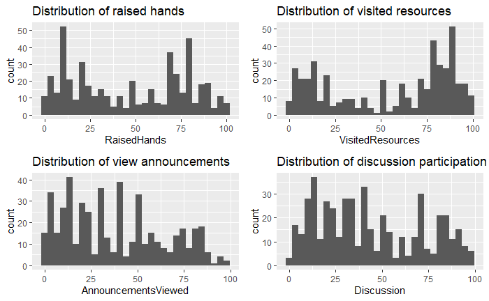

```r
grid.arrange(dist1, dist2, dist3, dist4, nrow=2)
```

```r
library(caret)
```

```r
#sample data 70%
RNGkind(sample.kind = "Rounding")
```

```
non-uniform 'Rounding' sampler used
```

```r
set.seed(123)
sample_index <- sample(1:nrow(grades_cleaned), size = floor(0.70*nrow(grades_cleaned)), replace = F)
train <- grades_cleaned[sample_index,]
test <- grades_cleaned[-sample_index,]
grades_actual <- test$Grade
head(train)
```

|  | gender | Nationality | PlaceofBirth | Education | GradeLevel | Classroom | Topic | Semester | Relation | RaisedHands | VisitedResources | AnnouncementsViewed | Discussion | ParentAnsweringSurvey | ParentschoolSatisfaction | StudentAbsenceDays | Grade |
| --- | --- | --- | --- | --- | --- | --- | --- | --- | --- | --- | --- | --- | --- | --- | --- | --- | --- |
| 139 | F | Jordan | Egypt | MiddleSchool | G-07 | A | Quran | F | Mum | 100 | 80 | 95 | 90 | No | Bad | Under-7 | H |
| 378 | M | Jordan | Jordan | lowerlevel | G-02 | B | Arabic | S | Mum | 32 | 82 | 59 | 63 | Yes | Bad | Above-7 | M |
| 196 | M | KW | KuwaIT | MiddleSchool | G-08 | A | Arabic | S | Father | 15 | 43 | 42 | 33 | Yes | Good | Under-7 | M |
| 422 | F | Jordan | Jordan | MiddleSchool | G-08 | A | Chemistry | S | Mum | 84 | 92 | 29 | 43 | Yes | Good | Under-7 | H |
| 448 | M | Jordan | Jordan | MiddleSchool | G-08 | A | Geology | S | Mum | 71 | 84 | 67 | 80 | Yes | Good | Under-7 | M |
| 22 | F | KW | KuwaIT | MiddleSchool | G-07 | B | IT | F | Father | 10 | 12 | 4 | 80 | No | Bad | Under-7 | M |

```r
glimpse(train)
```

```
Rows: 336
Columns: 17
$ gender                   <fct> F, M, M, F, M, F, M, F, M, M, M, M, M, M, F, M, M, M, M, M, M, F, ~
$ Nationality              <fct> Jordan, Jordan, KW, Jordan, Jordan, KW, KW, Jordan, KW, KW, Jordan~
$ PlaceofBirth             <fct> Egypt, Jordan, KuwaIT, Jordan, Jordan, KuwaIT, KuwaIT, Jordan, Kuw~
$ Education                <fct> MiddleSchool, lowerlevel, MiddleSchool, MiddleSchool, MiddleSchool~
$ GradeLevel               <fct> G-07, G-02, G-08, G-08, G-08, G-07, G-04, G-08, G-04, G-08, G-08, ~
$ Classroom                <fct> A, B, A, A, A, B, A, A, A, C, A, C, A, A, A, B, B, B, A, A, B, A, ~
$ Topic                    <fct> Quran, Arabic, Arabic, Chemistry, Geology, IT, Math, Geology, Hist~
$ Semester                 <fct> F, S, S, S, S, F, S, F, S, S, S, S, S, S, F, F, F, F, S, F, S, S, ~
$ Relation                 <fct> Mum, Mum, Father, Mum, Mum, Father, Father, Mum, Father, Father, M~
$ RaisedHands              <int> 100, 32, 15, 84, 71, 10, 15, 70, 10, 5, 81, 87, 50, 11, 70, 88, 11~
$ VisitedResources         <int> 80, 82, 43, 92, 84, 12, 6, 69, 17, 21, 84, 81, 90, 70, 4, 90, 2, 5~
$ AnnouncementsViewed      <int> 95, 59, 42, 29, 67, 4, 32, 46, 12, 42, 77, 42, 83, 32, 39, 76, 0, ~
$ Discussion               <int> 90, 63, 33, 43, 80, 80, 40, 45, 14, 14, 85, 19, 13, 29, 90, 81, 50~
$ ParentAnsweringSurvey    <fct> No, Yes, Yes, Yes, Yes, No, Yes, Yes, No, No, Yes, Yes, Yes, Yes, ~
$ ParentschoolSatisfaction <fct> Bad, Bad, Good, Good, Good, Bad, Good, Good, Bad, Good, Good, Good~
$ StudentAbsenceDays       <fct> Under-7, Above-7, Under-7, Under-7, Under-7, Under-7, Under-7, Abo~
$ Grade                    <fct> H, M, M, H, M, M, H, M, L, L, H, H, H, M, H, H, L, H, M, M, M, H, ~
```

The different grade categories are currently unbalanced. We would have do oversampling as the number of training samples are very little (336).

```r
table(train$Grade)
```

```
  L   M   H
 95 142  99
```

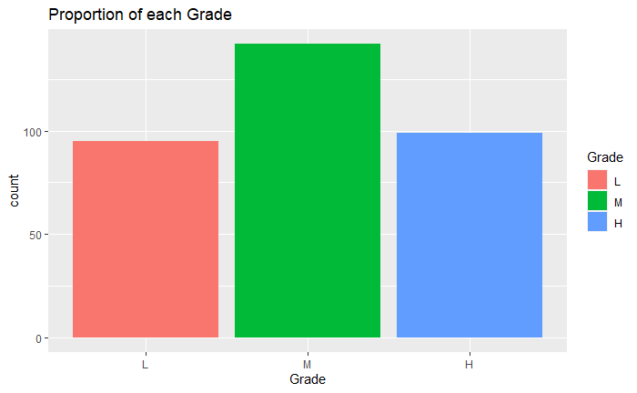

```r
ggplot(train, aes(fill=Grade, x=Grade)) +
  geom_bar() +
  ggtitle("Proportion of each Grade")
```

```r
RNGkind(sample.kind = "Rounding")
```

```
non-uniform 'Rounding' sampler used
```

```r
set.seed(123)
x <- train%>%select(-Grade)
y <- train$Grade
up_train <- upSample(x = x, y = y)
table(up_train$Class)
```

```
  L   M   H
142 142 142
```

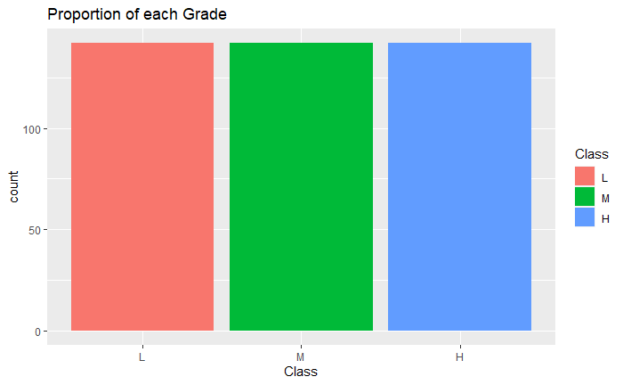

```r
ggplot(up_train, aes(fill=Class, x=Class)) +
  geom_bar() +
  ggtitle("Proportion of each Grade")
```

The classes are now balanced.

# Decision Tree

```r
library(tree)
```

```r
RNGkind(sample.kind = "Rounding")
```

```
non-uniform 'Rounding' sampler used
```

```r
set.seed(123)
grades_tree <- tree(Class~., up_train)
cv_grades <- cv.tree(grades_tree, FUN=prune.misclass)
optimal_nodes <- cv_grades$size[which.min(cv_grades$dev)]
prune_grades <- prune.misclass(grades_tree, best = optimal_nodes)
```

```r
predict_gradestree <- predict(prune_grades, newdata=test, type="class")
confusionMatrix(predict_gradestree, grades_actual, mode='everything')
```

```
Confusion Matrix and Statistics

          Reference
Prediction  L  M  H
         L 22  5  1
         M 10 51 17
         H  0 13 25

Overall Statistics

               Accuracy : 0.6806
                 95% CI : (0.5978, 0.7557)
    No Information Rate : 0.4792
    P-Value [Acc > NIR] : 8.327e-07

                  Kappa : 0.4835

 Mcnemar's Test P-Value : 0.3618

Statistics by Class:

                     Class: L Class: M Class: H
Sensitivity            0.6875   0.7391   0.5814
Specificity            0.9464   0.6400   0.8713
Pos Pred Value         0.7857   0.6538   0.6579
Neg Pred Value         0.9138   0.7273   0.8302
Precision              0.7857   0.6538   0.6579
Recall                 0.6875   0.7391   0.5814
F1                     0.7333   0.6939   0.6173
Prevalence             0.2222   0.4792   0.2986
Detection Rate         0.1528   0.3542   0.1736
Detection Prevalence   0.1944   0.5417   0.2639
Balanced Accuracy      0.8170   0.6896   0.7263
```

Decision Tree gives an accuracy score of 68.06% and the lowest F1 score of 61.73% from class H (students with highest range scores).

# Random Forest (Bagging)

```r
library(randomForest)
```

```r
#training the model
RNGkind(sample.kind = "Rounding")
```

```
non-uniform 'Rounding' sampler used
```

```r
set.seed(123)
grades_rf <- randomForest(Class~., data=up_train, importance=TRUE)
grades_rf
```

```
Call:
 randomForest(formula = Class ~ ., data = up_train, importance = TRUE)
               Type of random forest: classification
                     Number of trees: 500
No. of variables tried at each split: 4

        OOB estimate of  error rate: 15.02%
Confusion matrix:
    L   M   H class.error
L 134   8   0  0.05633803
M  12 108  22  0.23943662
H   0  22 120  0.15492958
```

```r
importance(grades_rf, type=1, scale = F)
```

```
                         MeanDecreaseAccuracy
gender                            0.011084420
Nationality                       0.023522779
PlaceofBirth                      0.019591909
Education                         0.004608699
GradeLevel                        0.021099785
Classroom                         0.005401456
Topic                             0.035241177
Semester                          0.002425242
Relation                          0.028116559
RaisedHands                       0.094552762
VisitedResources                  0.126330957
AnnouncementsViewed               0.060741853
Discussion                        0.027718799
ParentAnsweringSurvey             0.046165198
ParentschoolSatisfaction          0.014272386
StudentAbsenceDays                0.170948524
```

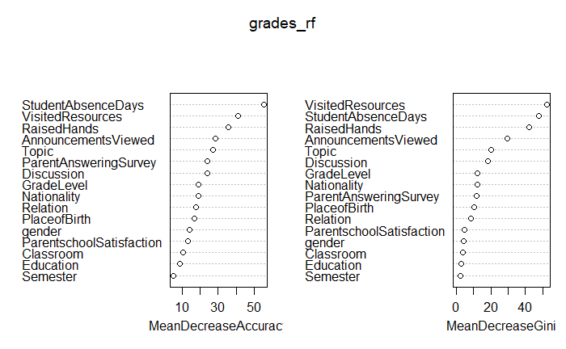

```r
varImpPlot(grades_rf)
```

The training model has an estimated error of 15.02%. This means that the estimated accuracy would be around 84.98%.

According to the Mean Decrease Accuracy graph, the top 3 most important variables that can negatively impact the accuracy of the model are the number of days students are absent (StudentAbsenceDays), the number of times students visited resources (VisitedResources), and the number of times students raised their hands and participate in class (RaisedHands).

The 3 least important variables are which class students are in (Classroom), their education level (Education) and the semester (Semester).

```r
#test the model
predict_gradesrf <- predict(grades_rf, newdata=test)
confusionMatrix(predict_gradesrf, grades_actual, mode='everything')
```

```
Confusion Matrix and Statistics

          Reference
Prediction  L  M  H
         L 26  7  0
         M  6 48 10
         H  0 14 33

Overall Statistics

               Accuracy : 0.7431
                 95% CI : (0.6636, 0.8122)
    No Information Rate : 0.4792
    P-Value [Acc > NIR] : 1.019e-10

                  Kappa : 0.5977

 Mcnemar's Test P-Value : NA

Statistics by Class:

                     Class: L Class: M Class: H
Sensitivity            0.8125   0.6957   0.7674
Specificity            0.9375   0.7867   0.8614
Pos Pred Value         0.7879   0.7500   0.7021
Neg Pred Value         0.9459   0.7375   0.8969
Precision              0.7879   0.7500   0.7021
Recall                 0.8125   0.6957   0.7674
F1                     0.8000   0.7218   0.7333
Prevalence             0.2222   0.4792   0.2986
Detection Rate         0.1806   0.3333   0.2292
Detection Prevalence   0.2292   0.4444   0.3264
Balanced Accuracy      0.8750   0.7412   0.8144
```

# Random Forest (Gradient Boosting)

```r
library(gbm)
```

```r
RNGkind(sample.kind = "Rounding")
```

```
non-uniform 'Rounding' sampler used
```

```r
set.seed(123)
grades_boost <- gbm(Class ~ . ,data = up_train, distribution = "multinomial", n.trees = 500, shrinkage = 0.01, interaction.depth = 4)
```

```
Setting `distribution = "multinomial"` is ill-advised as it is currently broken. It exists only for backwards compatibility. Use at your own risk.
```

```r
grades_boost
```

```
gbm(formula = Class ~ ., distribution = "multinomial",
    data = up_train, n.trees = 500, interaction.depth = 4, shrinkage = 0.01)
A gradient boosted model with multinomial loss function.
500 iterations were performed.
There were 16 predictors of which 16 had non-zero influence.
```

|  | var | rel.inf |
| --- | --- | --- |
| VisitedResources | VisitedResources | 22.7122870 |
| StudentAbsenceDays | StudentAbsenceDays | 21.5807742 |
| RaisedHands | RaisedHands | 13.6314097 |
| Topic | Topic | 11.2943085 |
| AnnouncementsViewed | AnnouncementsViewed | 6.3523885 |
| Nationality | Nationality | 4.7326353 |
| GradeLevel | GradeLevel | 4.3475085 |
| PlaceofBirth | PlaceofBirth | 3.7726491 |
| Discussion | Discussion | 3.7656115 |
| ParentAnsweringSurvey | ParentAnsweringSurvey | 2.9212875 |

[output cut: 6 more lines]

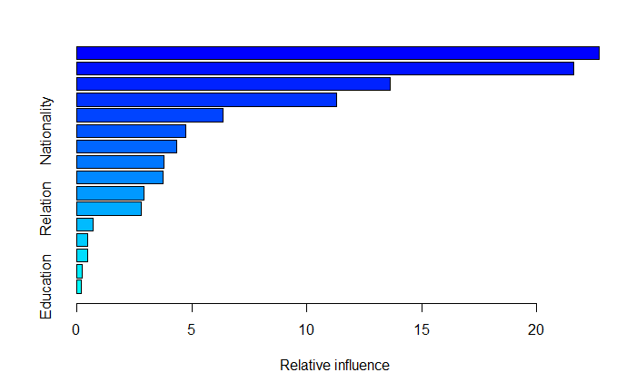

```r
summary(grades_boost)
```

According to the variable importance table, the 3 most important and 3 least important variables remain unchanged compared to Random Forest (Bagging). However, the order of the 3 most important variables differ where VisitedResources is the most important instead of StudentAbsenceDays.

```r
predict_gradesboost <- predict(grades_boost, test)
```

```
Using 500 trees...
```

```r
predictions <- colnames(predict_gradesboost)[apply(predict_gradesboost, 1, which.max)]
confusionMatrix(as.factor(predictions), grades_actual, mode='everything')
```

```
Levels are not in the same order for reference and data. Refactoring data to match.
```

```
Confusion Matrix and Statistics

          Reference
Prediction  L  M  H
         L 25  8  0
         M  7 44 11
         H  0 17 32

Overall Statistics

               Accuracy : 0.7014
                 95% CI : (0.6196, 0.7747)
    No Information Rate : 0.4792
    P-Value [Acc > NIR] : 5.545e-08

                  Kappa : 0.5343

 Mcnemar's Test P-Value : NA

Statistics by Class:

                     Class: L Class: M Class: H
Sensitivity            0.7812   0.6377   0.7442
Specificity            0.9286   0.7600   0.8317
Pos Pred Value         0.7576   0.7097   0.6531
Neg Pred Value         0.9369   0.6951   0.8842
Precision              0.7576   0.7097   0.6531
Recall                 0.7812   0.6377   0.7442
F1                     0.7692   0.6718   0.6957
Prevalence             0.2222   0.4792   0.2986
Detection Rate         0.1736   0.3056   0.2222
Detection Prevalence   0.2292   0.4306   0.3403
Balanced Accuracy      0.8549   0.6988   0.7879
```

The overall accuracy is 70.14% with the lowest F1 score of 67.18% for class M, students who got medium range scores.

# Support Vector Machine (SVM)

```r
library(e1071)
```

```r
RNGkind(sample.kind = "Rounding")
```

```
non-uniform 'Rounding' sampler used
```

```r
set.seed(123)
grades_svm <- svm(Class~., data=up_train,
          method="C-classification", kernal="radial",
          gamma=0.1, cost=10)
summary(grades_svm)
```

```
Call:
svm(formula = Class ~ ., data = up_train, method = "C-classification", kernal = "radial",
    gamma = 0.1, cost = 10)


Parameters:
   SVM-Type:  C-classification
 SVM-Kernel:  radial
       cost:  10

Number of Support Vectors:  252

 ( 47 117 88 )


Number of Classes:  3

Levels:
 L M H
```

```r
varImp(grades_svm)
```

[output not shown]

# Conclusion

The 3 most important features in predicting students’ grade classes will be StudentAbsenceDays, VisitedResources and RaisedHands, according to the feature importance from Random Forest (Bagging) and Random Forest (Gradient Boosting). These features will most likely be of high importance in SVM too.